# Classification

So we will create visualizing grid based on x1, x2, and z and w.  
For rest of features use their median values based on the training set.

```r
viz_grid <- expand.grid(x1 = seq(min(df_derived_cat$x1), max(df_derived_cat$x1), length.out = 51),
                        x2 = seq(min(df_derived_cat$x2), max(df_derived_cat$x2), length.out = 5),
                        x3 = median(df_derived_cat$x3),
                        x4 = median(df_derived_cat$x4),
                        x5 = median(df_derived_cat$x5),
                        v1 = median(df_derived_cat$v1),
                        v2 = median(df_derived_cat$v2),
                        v3 = median(df_derived_cat$v3),
                        v4 = median(df_derived_cat$v4),
                        v5 = median(df_derived_cat$v5),
                        w = seq(min(df_derived_cat$w), max(df_derived_cat$w), length.out = 5),
                        z = seq(min(df_derived_cat$z), max(df_derived_cat$z), length.out = 51),
                        t = median(df_derived_cat$t),
                        m = c("A", "B"),
                        KEEP.OUT.ATTRS = FALSE,
                        stringsAsFactors = FALSE) %>%
  as.data.frame() %>% tibble::as_tibble()

viz_grid %>% glimpse()
```

```
## Rows: 130,050
## Columns: 14
## $ x1 <dbl> 0.0031170, 0.0152365, 0.0273560, 0.0394755, 0.0515950, 0.0637145, 0…
## $ x2 <dbl> 0.001173, 0.001173, 0.001173, 0.001173, 0.001173, 0.001173, 0.00117…
## $ x3 <dbl> 0.2635515, 0.2635515, 0.2635515, 0.2635515, 0.2635515, 0.2635515, 0…
## $ x4 <dbl> 0.0558215, 0.0558215, 0.0558215, 0.0558215, 0.0558215, 0.0558215, 0…
## $ x5 <dbl> 0.1857175, 0.1857175, 0.1857175, 0.1857175, 0.1857175, 0.1857175, 0…
## $ v1 <dbl> 5.13715, 5.13715, 5.13715, 5.13715, 5.13715, 5.13715, 5.13715, 5.13…
## $ v2 <dbl> 0.5151535, 0.5151535, 0.5151535, 0.5151535, 0.5151535, 0.5151535, 0…
## $ v3 <dbl> 5.631905, 5.631905, 5.631905, 5.631905, 5.631905, 5.631905, 5.63190…
## $ v4 <dbl> 0.489235, 0.489235, 0.489235, 0.489235, 0.489235, 0.489235, 0.48923…
## $ v5 <dbl> 6.496589, 6.496589, 6.496589, 6.496589, 6.496589, 6.496589, 6.49658…
## $ w  <dbl> 0.002641605, 0.002641605, 0.002641605, 0.002641605, 0.002641605, 0.…
## $ z  <dbl> 0.03435744, 0.03435744, 0.03435744, 0.03435744, 0.03435744, 0.03435…
## $ t  <dbl> 2.364547, 2.364547, 2.364547, 2.364547, 2.364547, 2.364547, 2.36454…
## $ m  <chr> "A", "A", "A", "A", "A", "A", "A", "A", "A", "A", "A", "A", "A", "A…
```

```r
viz_grid %>% purrr::map_dbl(n_distinct)
```

```
## x1 x2 x3 x4 x5 v1 v2 v3 v4 v5  w  z  t  m
## 51  5  1  1  1  1  1  1  1  1  5 51  1  2
```

```r
predict(final_rf_base_fit, new_data = viz_grid) %>%
  glimpse()
```

```
## Rows: 130,050
## Columns: 1
## $ .pred_class <fct> non-event, non-event, non-event, non-event, non-event, non…
```

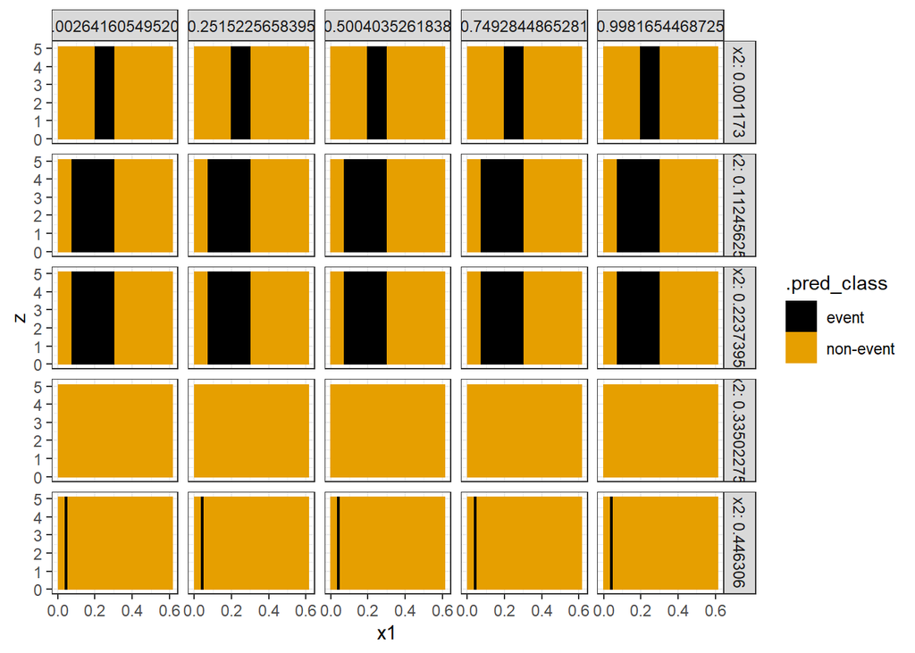

```r
viz_grid %>%
  bind_cols(predict(final_rf_base_fit, new_data = viz_grid)) %>%
  ggplot(mapping = aes(x = x1, y = z)) +
  geom_raster(mapping = aes(fill = .pred_class)) +
  facet_grid(x2 ~ w, labeller = "label_both") +
  ggthemes::scale_fill_colorblind() +
  theme_bw()
```

The random forest base model is classifying non-event for almost all values of x2 > 0.3.

```r
predict(final_rf_base_fit, new_data = viz_grid, type = 'prob') %>%
  glimpse()
```

```
## Rows: 130,050
## Columns: 2
## $ .pred_event       <dbl> 0.00000000, 0.00000000, 0.00000000, 0.01483810, 0.06…
## $ `.pred_non-event` <dbl> 1.00000000, 1.00000000, 1.00000000, 0.98516190, 0.93…
```

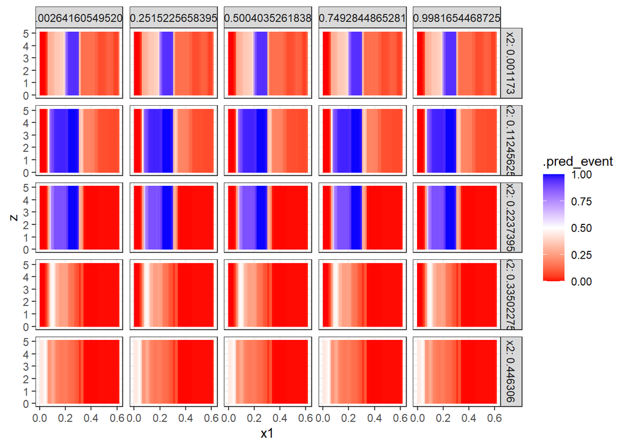

```r
viz_grid %>%
  bind_cols(predict(final_rf_base_fit, new_data = viz_grid, type='prob')) %>%
  ggplot(mapping = aes(x = x1, y = z)) +
  geom_raster(mapping = aes(fill = .pred_event)) +
  facet_grid(x2 ~ w, labeller = "label_both") +
  scale_fill_gradient2(low = 'red', mid = 'white', high = 'blue',
                       midpoint = 0.5,
                       limits = c(0, 1)) +
  theme_bw()
```

The bottom 2 rows have probabilities predictions less than 0.5.

**Looking at the predictions with random forest model using expanded features set.**

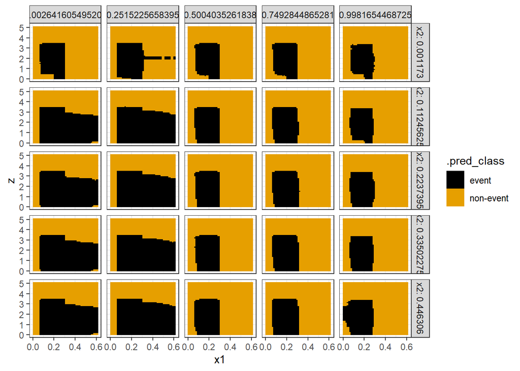

```r
viz_grid %>%
  bind_cols(predict(final_rf_exp_fit, new_data = viz_grid)) %>%
  ggplot(mapping = aes(x = x1, y = z)) +
  geom_raster(mapping = aes(fill = .pred_class)) +
  facet_grid(x2 ~ w, labeller = "label_both") +
  ggthemes::scale_fill_colorblind() +
  theme_bw()
```

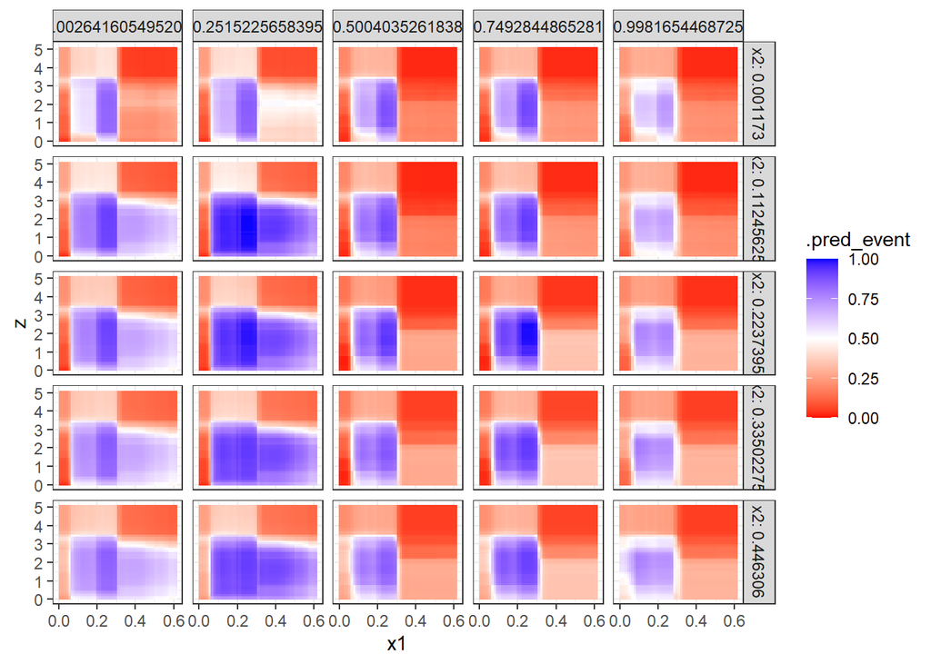

```r
viz_grid %>%
  bind_cols(predict(final_rf_exp_fit, new_data = viz_grid, type='prob')) %>%
  ggplot(mapping = aes(x = x1, y = z)) +
  geom_raster(mapping = aes(fill = .pred_event)) +
  facet_grid(x2 ~ w, labeller = "label_both") +
  scale_fill_gradient2(low = 'red', mid = 'white', high = 'blue',
                       midpoint = 0.5,
                       limits = c(0, 1)) +
  theme_bw()
```

```r
if(parallel::detectCores(logical=FALSE) > 3){
  stopCluster(cl)
}
```